# Assignment #2 - AMOD 5250H

Ali Tahsili

**Make sure your solution to each question includes enough output to show that your solution is correct (i.e if asked to create a vector, output the vector afterwards)**

## Question 1 - Graph Customization [7 marks]

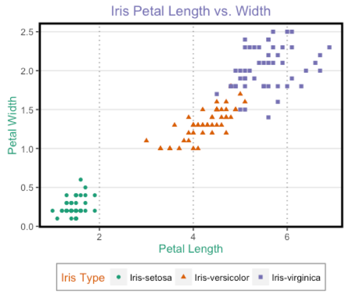

Use the `iris` dataset from the `datasets` package. Produce a scatterplot of petal length vs petal width using ggplot2. Modify the resulting graph so that it matches the above.

- Color codes: ‘#1b9e77’,‘#d95f02’,‘#7570b3’
- Major x axis lines: grey90
- Major y axis lines: grey60
- No minor axis lines

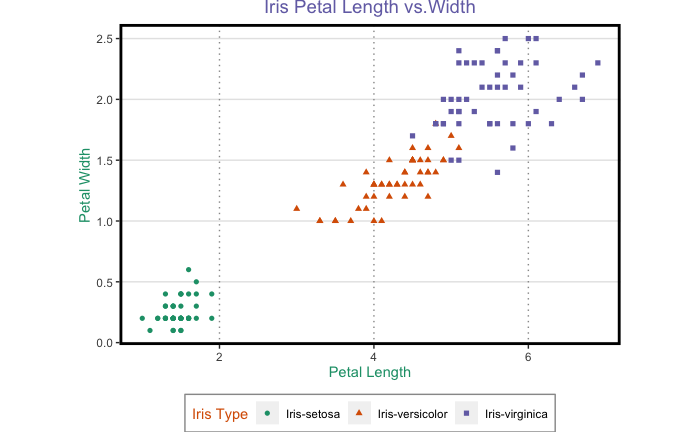

```r
Color_codes <- c('#1b9e77','#d95f02','#7570b3')
iris %>%
  ggplot(aes(Petal.Length, Petal.Width, color = Species, shape = Species)) +
  geom_point() +
  # Title renamed
labs(title = "Iris Petal Length vs.Width") +
  # x-label renamed
xlab("Petal Length") +
  # y-label renamed
ylab("Petal Width") +
  # Legend texts renamed (Specify both color and shape)
scale_shape_discrete(
  name = "Iris Type",
  breaks=c("setosa", "versicolor", "virginica"),
  labels = c("Iris-setosa", "Iris-versicolor", "Iris-virginica")) +
scale_color_manual(
  name = "Iris Type", values = Color_codes,
  breaks=c("setosa", "versicolor", "virginica"),
  labels = c("Iris-setosa", "Iris-versicolor", "Iris-virginica")) +
  # Title Specification
theme(plot.title = element_text(hjust = 0.5, size = 14, color = '#7570b3'),
  # Axis x Specification
  axis.title.x = element_text(colour = '#1b9e77'),
  # Axis y Specification
  axis.title.y = element_text(colour = '#1b9e77'),
  # Legend Specification
  legend.position="bottom",
  legend.background=element_rect(color="grey60"),
  legend.title = element_text(colour="#d95f02"),
  # Panel Specification
  panel.background = element_rect(fill = "white"),
  panel.grid.major.x = element_line(colour = "grey60", linetype = "dotted"),
  panel.grid.major.y=element_line(colour = "grey90"),
  panel.grid.minor = element_blank(),
  panel.border = element_rect(fill=NA, size = 2, color = "black"),
  # change dimension of the plot
  plot.margin = margin(0, 2.1, 0, 2.1, "cm"))
```

## Question 2 -Dplyr [8 marks]

Use the `mtcars` dataset and the tools in the **dplyr** library to complete the following tasks:

1. Return rows of cars that have an `mpg` value greater than 20 and 6 cylinders. [1 mark]

```r
mtcars %>%
  filter(mpg > 20, cyl == 6)
```

|  | mpg | cyl | disp | hp | drat | wt | qsec | vs | am | gear | carb |
| --- | --- | --- | --- | --- | --- | --- | --- | --- | --- | --- | --- |
| Mazda RX4 | 21.0 | 6 | 160 | 110 | 3.90 | 2.620 | 16.46 | 0 | 1 | 4 | 4 |
| Mazda RX4 Wag | 21.0 | 6 | 160 | 110 | 3.90 | 2.875 | 17.02 | 0 | 1 | 4 | 4 |
| Hornet 4 Drive | 21.4 | 6 | 258 | 110 | 3.08 | 3.215 | 19.44 | 1 | 0 | 3 | 1 |

2. Reorder the Data Frame by `cyl` first, then by descending `wt`. [1 mark]

```r
mtcars %>%
  arrange(cyl, desc(wt))
```

|  | mpg | cyl | disp | hp | drat | wt | qsec | vs | am | gear | carb |
| --- | --- | --- | --- | --- | --- | --- | --- | --- | --- | --- | --- |
| Merc 240D | 24.4 | 4 | 146.7 | 62 | 3.69 | 3.190 | 20.00 | 1 | 0 | 4 | 2 |
| Merc 230 | 22.8 | 4 | 140.8 | 95 | 3.92 | 3.150 | 22.90 | 1 | 0 | 4 | 2 |
| Volvo 142E | 21.4 | 4 | 121.0 | 109 | 4.11 | 2.780 | 18.60 | 1 | 1 | 4 | 2 |
| Toyota Corona | 21.5 | 4 | 120.1 | 97 | 3.70 | 2.465 | 20.01 | 1 | 0 | 3 | 1 |
| Datsun 710 | 22.8 | 4 | 108.0 | 93 | 3.85 | 2.320 | 18.61 | 1 | 1 | 4 | 1 |
| Fiat 128 | 32.4 | 4 | 78.7 | 66 | 4.08 | 2.200 | 19.47 | 1 | 1 | 4 | 1 |
| Porsche 914-2 | 26.0 | 4 | 120.3 | 91 | 4.43 | 2.140 | 16.70 | 0 | 1 | 5 | 2 |
| Fiat X1-9 | 27.3 | 4 | 79.0 | 66 | 4.08 | 1.935 | 18.90 | 1 | 1 | 4 | 1 |
| Toyota Corolla | 33.9 | 4 | 71.1 | 65 | 4.22 | 1.835 | 19.90 | 1 | 1 | 4 | 1 |
| Honda Civic | 30.4 | 4 | 75.7 | 52 | 4.93 | 1.615 | 18.52 | 1 | 1 | 4 | 2 |

[output cut: 22 more lines]

3. Return a dataframe which contains just the `mpg` and `hp` columns. [1 mark]

```r
mtcars %>%
  select(mpg,hp)
```

|  | mpg | hp |
| --- | --- | --- |
| Mazda RX4 | 21.0 | 110 |
| Mazda RX4 Wag | 21.0 | 110 |
| Datsun 710 | 22.8 | 93 |
| Hornet 4 Drive | 21.4 | 110 |
| Hornet Sportabout | 18.7 | 175 |
| Valiant | 18.1 | 105 |
| Duster 360 | 14.3 | 245 |
| Merc 240D | 24.4 | 62 |
| Merc 230 | 22.8 | 95 |
| Merc 280 | 19.2 | 123 |

[output cut: 22 more lines]

4. Return the distinct values of the `gear` column. [1 mark]

```r
library(knitr)
mtcars %>%
  distinct(gear) %>%
    kable(format = "markdown")
```

|  | gear |
| --- | --- |
| Mazda RX4 | 4 |
| Hornet 4 Drive | 3 |
| Porsche 914-2 | 5 |

5. Create a new column called “Performance” which is calculated by `hp` divided by `wt`. [1 mark]

```r
mtcars %>%
  mutate(Performance = hp/wt)
```

|  | mpg | cyl | disp | hp | drat | wt | qsec | vs | am | gear | carb | Performance |
| --- | --- | --- | --- | --- | --- | --- | --- | --- | --- | --- | --- | --- |
| Mazda RX4 | 21.0 | 6 | 160.0 | 110 | 3.90 | 2.620 | 16.46 | 0 | 1 | 4 | 4 | 41.98473 |
| Mazda RX4 Wag | 21.0 | 6 | 160.0 | 110 | 3.90 | 2.875 | 17.02 | 0 | 1 | 4 | 4 | 38.26087 |
| Datsun 710 | 22.8 | 4 | 108.0 | 93 | 3.85 | 2.320 | 18.61 | 1 | 1 | 4 | 1 | 40.08621 |
| Hornet 4 Drive | 21.4 | 6 | 258.0 | 110 | 3.08 | 3.215 | 19.44 | 1 | 0 | 3 | 1 | 34.21462 |
| Hornet Sportabout | 18.7 | 8 | 360.0 | 175 | 3.15 | 3.440 | 17.02 | 0 | 0 | 3 | 2 | 50.87209 |
| Valiant | 18.1 | 6 | 225.0 | 105 | 2.76 | 3.460 | 20.22 | 1 | 0 | 3 | 1 | 30.34682 |
| Duster 360 | 14.3 | 8 | 360.0 | 245 | 3.21 | 3.570 | 15.84 | 0 | 0 | 3 | 4 | 68.62745 |
| Merc 240D | 24.4 | 4 | 146.7 | 62 | 3.69 | 3.190 | 20.00 | 1 | 0 | 4 | 2 | 19.43574 |
| Merc 230 | 22.8 | 4 | 140.8 | 95 | 3.92 | 3.150 | 22.90 | 1 | 0 | 4 | 2 | 30.15873 |
| Merc 280 | 19.2 | 6 | 167.6 | 123 | 3.92 | 3.440 | 18.30 | 1 | 0 | 4 | 4 | 35.75581 |

[output cut: 22 more lines]

6. Find the overall mean mpg. [1 mark]

```r
mtcars %>%
  summarise(Average_mpg = mean(mpg))
```

| Average_mpg |
| --- |
| 20.09062 |

7. Use pipe operators to get the mean hp value for cars with 6 cylinders. [2 marks]

```r
mtcars %>%
  filter(cyl == 6) %>%
  summarise(mean(hp))
```

| mean(hp) |
| --- |
| 122.2857 |

## Question 3 - Joining [10 marks]

Use **dplyr** and mutating/filter joins to briefly answer the following questions (your answers should include inline RMarkdown where relevent). You will need to use the `nycflights13` data set examined in class.

1. Create a dataframe which extends the flights dataframe with location of the origin and destination (i.e. the lat and lon). [2 marks]

```r
flights %>%
  # Extend with origin location
  left_join(select(airports, origin = faa, origin_lat = lat, origin_lon = lon),
             by = "origin") %>%
  # Extend with destination location
  left_join(select(airports, dest = faa, dest_lat = lat, dest_lon = lon),
             by = "dest") %>%
    kable(format = "markdown")
```

[output not shown]

2. Is there a relationship between the age of a plane and its delays? [2 marks]

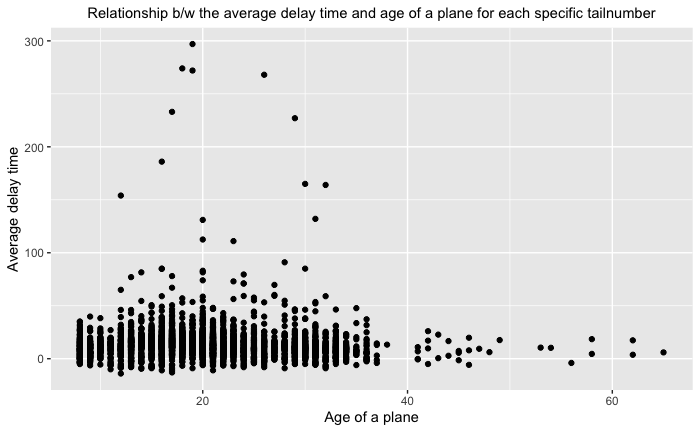

```r
planes %>%
  # Select tailnum column and create age column
  transmute(tailnum, age = 2021-year) %>%
  # Join with flights data by tailnum column
  inner_join(select(flights, tailnum, dep_delay), by = "tailnum") %>%
  # Group data by tailnum and age
  group_by(tailnum, age) %>%
  # Remove the NA observations for age and dep_delay columns
  filter(!is.na(age),!is.na(dep_delay)) %>%
  # Calculate the average dep_delay per tailnumber and age
  summarise(Mean_dep_delay = mean(dep_delay)) %>%
  # Draw the relationship b/w age and delay time considering for each tailnumber
  ggplot(aes(age, Mean_dep_delay)) +
  geom_point() +
  xlab ("Age of a plane") +
  ylab("Average delay time") +
  labs(title = "Relationship b/w the average delay time and age of a plane for each specific tailnumber") +
  theme(plot.title = element_text(hjust = 0.5, size = 11))
```

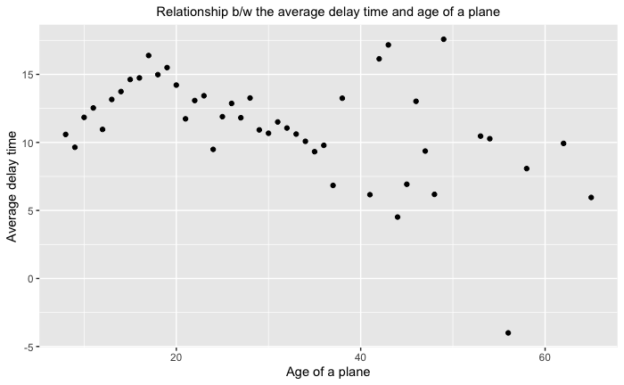

```r
planes %>%
  # Select tailnum column and create age column
  transmute(tailnum, age = 2021-year) %>%
  # Join with flights data by tailnum column
  inner_join(select(flights, tailnum, dep_delay), by = "tailnum") %>%
  # Group data only by age
  group_by(age) %>%
  # Remove the NA observations for age and dep_delay columns
  filter(!is.na(age),!is.na(dep_delay)) %>%
  # Calculate the average dep_delay for an each age
  summarise(Mean_dep_delay = mean(dep_delay)) %>%
  # Draw the relationship b/w age and delay time
  ggplot(aes(age, Mean_dep_delay)) +
  geom_point() +
  xlab ("Age of a plane") +
  ylab("Average delay time") +
  labs(title = "Relationship b/w the average delay time and age of a plane") +
  theme(plot.title = element_text(hjust = 0.5, size = 11))
```

The first plot shows the relationship between the average delay time and the age of a plane for each specific tail number. As we can see, we cannot conclude any clear relationship between these two features. Thus, I generated the second plot by not considering the tail number. Therefore, I grouped them by age to see any relationship between plane age and delay time. As it is clear, again, there is no relationship between these two.

3. What weather conditions make it more likely to see a delay? [2 marks]

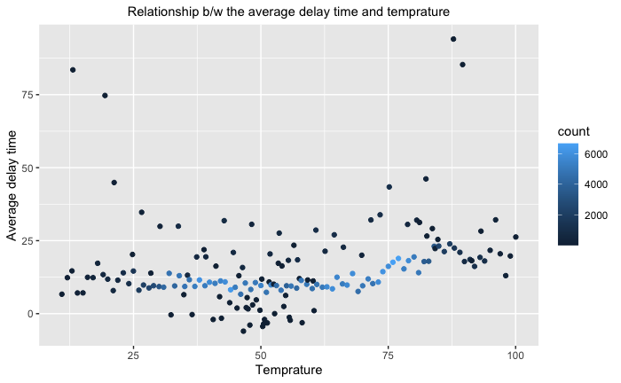

```r
TempVsDelay <- weather %>%
  # Join the weather data frame with flights data to see the dep_delay
  inner_join(select(flights, year, month, day, hour, origin, dep_delay),
             by = c("year", "month", "day", "hour", "origin")) %>%
  # Remove NA observations for dep_delay and temp column
  filter(!is.na(dep_delay), !is.na(temp)) %>%
  # Group them by temp
  group_by(temp) %>%
  # Calculate the number and average of the dep_delay for each temperature
  summarise(count= n(), Ave_delay = mean(dep_delay))

  # Plot the data to see any relationship b/w temperature and delay time
  TempVsDelay %>%
    ggplot(aes(temp, Ave_delay, color = count)) +
    geom_point() +
    xlab ("Temprature") +
    ylab("Average delay time") +
    labs(title = "Relationship b/w the average delay time and temprature") +
    theme(plot.title = element_text(hjust = 0.5, size = 11))
```

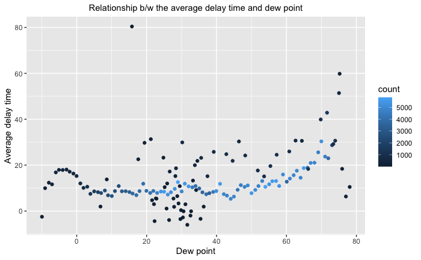

```r
# Specify the boundaries for high occurrence
Temp <- TempVsDelay %>%
  filter (count > 4000) %>%
  arrange(temp)

# I did the same for other weather conditions to see the relationship b/w delay time and the weather conditions.

DewpVsDelay <- weather %>%
  inner_join(select(flights, year, month, day, hour, origin, dep_delay),
             by = c("year", "month", "day", "hour", "origin")) %>%
  filter(!is.na(dep_delay), !is.na(dewp)) %>%
  group_by(dewp) %>%
  summarise(count= n(), Ave_delay = mean(dep_delay))

  DewpVsDelay %>%
    ggplot(aes(dewp, Ave_delay, color = count)) +
    geom_point() +
    xlab ("Dew point") +
    ylab("Average delay time") +
    labs(title = "Relationship b/w the average delay time and dew point") +
    theme(plot.title = element_text(hjust = 0.5, size = 11))
```

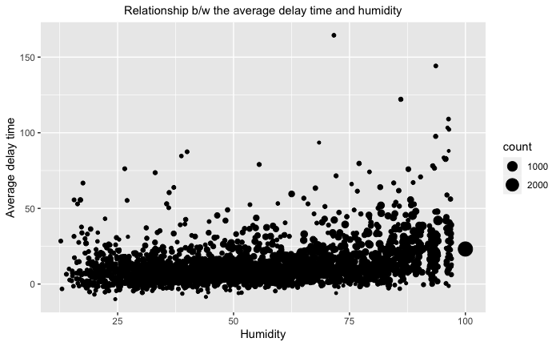

```r
Dewp <- DewpVsDelay %>%
  filter (count > 4000) %>%
  arrange(dewp)

HumidVsDelay <- weather %>%
  inner_join(select(flights, year, month, day, hour, origin, dep_delay),
             by = c("year", "month", "day", "hour", "origin")) %>%
  filter(!is.na(dep_delay), !is.na(humid)) %>%
  group_by(humid) %>%
  summarise(count= n(), Ave_delay = mean(dep_delay))

  HumidVsDelay %>%
    ggplot(aes(humid, Ave_delay, size = count)) +
    geom_point() +
    xlab ("Humidity") +
    ylab("Average delay time") +
    labs(title = "Relationship b/w the average delay time and humidity") +
    theme(plot.title = element_text(hjust = 0.5, size = 11))
```

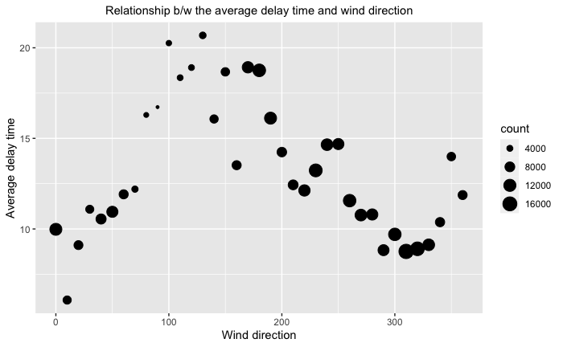

```r
Humid <- HumidVsDelay %>%
  filter (count > 2000) %>%
  arrange(humid)

Wind_dirVsDelay <- weather %>%
  inner_join(select(flights, year, month, day, hour, origin, dep_delay),
             by = c("year", "month", "day", "hour", "origin")) %>%
  filter(!is.na(dep_delay), !is.na(wind_dir)) %>%
  group_by(wind_dir) %>%
  summarise(count= n(), Ave_delay = mean(dep_delay))

  Wind_dirVsDelay %>%
    ggplot(aes(wind_dir, Ave_delay, size = count)) +
    geom_point() +
    xlab ("Wind direction") +
    ylab("Average delay time") +
    labs(title = "Relationship b/w the average delay time and wind direction") +
    theme(plot.title = element_text(hjust = 0.5, size = 11))
```

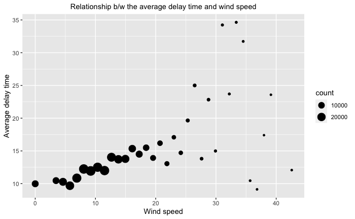

```r
Wind_dir <- Wind_dirVsDelay %>%
  filter (Ave_delay > 15, count > 5000) %>%
  arrange(wind_dir)

Wind_speedVsDelay <- weather %>%
  inner_join(select(flights, year, month, day, hour, origin, dep_delay),
             by = c("year", "month", "day", "hour", "origin")) %>%
  filter(!is.na(dep_delay), !is.na(wind_speed)) %>%
  group_by(wind_speed) %>%
  summarise(count= n(), Ave_delay = mean(dep_delay))

  Wind_speedVsDelay %>%
    ggplot(aes(wind_speed, Ave_delay, size = count)) +
    geom_point() +
    xlab ("Wind speed") +
    ylab("Average delay time") +
    labs(title = "Relationship b/w the average delay time and wind speed") +
    theme(plot.title = element_text(hjust = 0.5, size = 11))
```

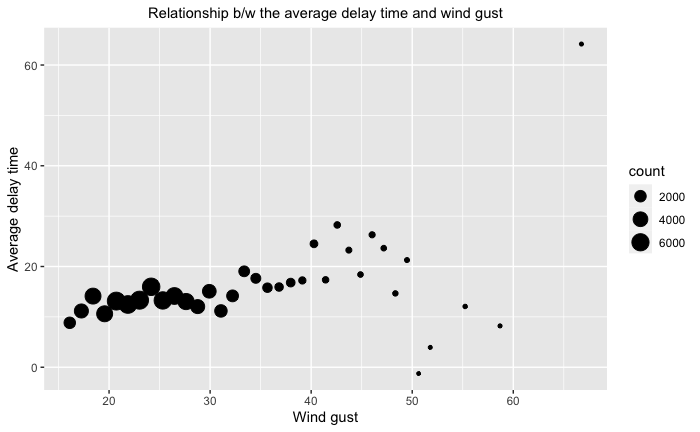

```r
Wind_speed <- Wind_speedVsDelay %>%
  filter (count > 5000) %>%
  arrange(wind_speed)


Wind_gustVsDelay <- weather %>%
  inner_join(select(flights, year, month, day, hour, origin, dep_delay),
             by = c("year", "month", "day", "hour", "origin")) %>%
  filter(!is.na(dep_delay), !is.na(wind_gust)) %>%
  group_by(wind_gust) %>%
  summarise(count= n(), Ave_delay = mean(dep_delay))

  Wind_gustVsDelay %>%
    ggplot(aes(wind_gust, Ave_delay, size = count)) +
    geom_point() +
    xlab ("Wind gust") +
    ylab("Average delay time") +
    labs(title = "Relationship b/w the average delay time and wind gust") +
    theme(plot.title = element_text(hjust = 0.5, size = 11))
```

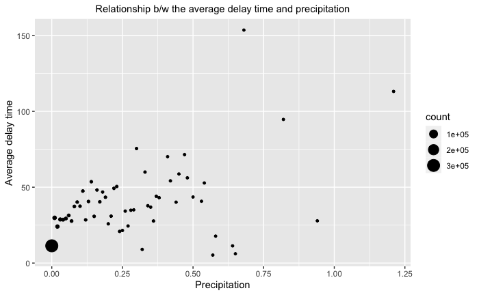

```r
PrecipVsDelay <- weather %>%
  inner_join(select(flights, year, month, day, hour, origin, dep_delay),
             by = c("year", "month", "day", "hour", "origin")) %>%
  filter(!is.na(dep_delay), !is.na(precip)) %>%
  group_by(precip) %>%
  summarise(count= n(), Ave_delay = mean(dep_delay))

  PrecipVsDelay %>%
    ggplot(aes(precip, Ave_delay, size = count)) +
    geom_point() +
    xlab ("Precipitation") +
    ylab("Average delay time") +
    labs(title = "Relationship b/w the average delay time and precipitation") +
    theme(plot.title = element_text(hjust = 0.5, size = 11))
```

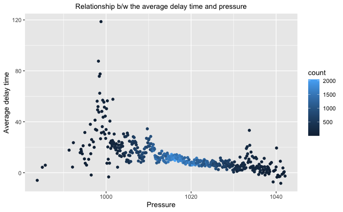

```r
PressureVsDelay <- weather %>%
  inner_join(select(flights, year, month, day, hour, origin, dep_delay),
             by = c("year", "month", "day", "hour", "origin")) %>%
  filter(!is.na(dep_delay), !is.na(pressure)) %>%
  group_by(pressure) %>%
  summarise(count= n(), Ave_delay = mean(dep_delay))

  PressureVsDelay %>%
    ggplot(aes(pressure, Ave_delay, color = count)) +
    geom_point() +
    xlab ("Pressure") +
    ylab("Average delay time") +
    labs(title = "Relationship b/w the average delay time and pressure") +
    theme(plot.title = element_text(hjust = 0.5, size = 11))
```

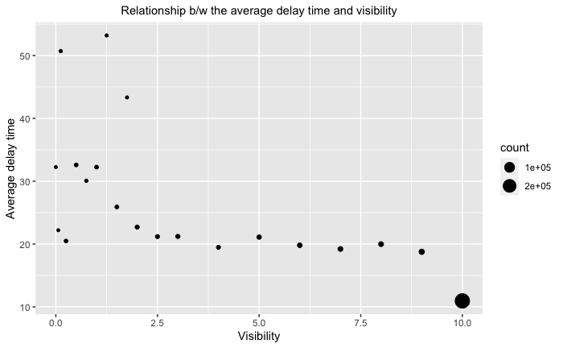

```r
Pressure <- PressureVsDelay %>%
  filter (count > 1500) %>%
  arrange(pressure)

VisibVsDelay  <- weather %>%
  inner_join(select(flights, year, month, day, hour, origin, dep_delay),
             by = c("year", "month", "day", "hour", "origin")) %>%
  filter(!is.na(dep_delay), !is.na(visib)) %>%
  group_by(visib) %>%
  summarise(count= n(), Ave_delay = mean(dep_delay))

  VisibVsDelay %>%
    ggplot(aes(visib, Ave_delay, size = count)) +
    geom_point() +
    xlab ("Visibility") +
    ylab("Average delay time") +
    labs(title = "Relationship b/w the average delay time and visibility") +
    theme(plot.title = element_text(hjust = 0.5, size = 11))
```

```r
Visib <- VisibVsDelay %>%
  filter (count > 5000) %>%
  arrange(visib)
```

I investigated the nine weather conditions that might influence a delay time in flights. These conditions are temperature, dew point, humidity, wind direction, wind speed, wind gust, precipitation, pressure and visibility.

From the first figure, most of the flights occur from 31 to 81 Fahrenheit degree temprature. However, there is no clear relationship between temperature and delay time.

In the second figure, most of the flights occur between 21 to 71 dew point. We can see a slight increase in delay time as the dew point rises.

In figure 5, a few flights with a wind speed of more than 21 mph have more delay time. In general, delay time rises as wind speed increases.

Figure 6 shows the relationship between delay time and wind gust. For most of the observations, there is no number of wind gusts. As we can see from the figure, there is no clear relationship between these two.

In figure 7, as we can see, most flights occur in a day without rain; however, delay time increase as precipitation increases. The following figure indicates in the pressure between 1013.5 and 1021.8 millibars; we have the most flights.

In the last figure, we can see, most of the flights occur in visibility between 6 and 10. More importantly, around 90% of the flights occur in complete visibility; however, a delay time increases as visibility decreases.

4. What information does `anti_join(flights, airports, by = c("dest" = "faa"))` provide for you? What does `anti_join (airports, flights, by = c("faa" = "dest"))` tell you? [2 marks]

```r
# Destinations in flight data frame with no faa-code
(dest_no_faa <- anti_join(flights, airports,
          by = c("dest" = "faa")) %>%
  select(dest, everything()) %>%
  distinct(dest))
```

| dest |
| --- |
| BQN |
| SJU |
| STT |
| PSE |

```r
# Check whether is there any faa-code with these destination?
airports %>%
  filter(faa == "BQN", faa == "SJU", faa == "STT", faa == "PSE")
```

| faa | name | lat | lon | alt | tz | dst | tzone |
| --- | --- | --- | --- | --- | --- | --- | --- |

```r
# Faa codes in airports data frame with no destination in flight data frame
(faa_no_dest_flight <- anti_join(airports, flights,
           by = c("faa" = "dest")) %>%
  select(faa, everything()) %>%
  distinct(faa))
```

| faa |
| --- |
| 04G |
| 06A |
| 06C |
| 06N |
| 09J |
| 0A9 |
| 0G6 |
| 0G7 |
| 0P2 |
| 0S9 |

[output cut: 990 more lines]

```r
# Check whether is there any destination with these faa-code?
flights %>%
  filter(dest == "04G", dest == "06A", dest == "0G6", dest == "0S9")
```

| year | month | day | dep_time | sched_dep_time | dep_delay | arr_time | sched_arr_time | arr_delay | carrier | flight | tailnum | origin | dest | air_time | distance | hour | minute | time_hour |
| --- | --- | --- | --- | --- | --- | --- | --- | --- | --- | --- | --- | --- | --- | --- | --- | --- | --- | --- |

`anti_join(flights, airports, by = c("dest" = "faa"))` Part1: It returns all the destinations in the “flights” data frame, which does not have a faa code in the “airports” data frame. By distinct() function, we can see 4 destinations that do not have a faa code (BQN, SJU, STT, PSE). We can check them by filtering the “airports” data frame to show only these destinations’ observations, which returns 0 observations.

`anti_join (airports, flights, by = c("faa" = "dest"))` Part2: This code shows all the faa codes not in the destination of the “flights” data frame. 1357 airports were not a destination for all the flights that occurred from NY in 2013. We can check this by filtering some of the faa codes in the “airports” data frame, which returns 0 observations.

5. You might expect that there’s an implicit relationship between plane and airline, because each plane is flown by a single airline. Confirm or reject this hypothesis. [2 marks]

```r
# Find the number of planes for each carrier
(CarrierVsTailnum <- flights %>%
  group_by(carrier) %>%
  summarise(N_of_planes = n_distinct(tailnum)))
```

| carrier | N_of_planes |
| --- | --- |
| 9E | 204 |
| AA | 601 |
| AS | 84 |
| B6 | 193 |
| DL | 629 |
| EV | 316 |
| F9 | 26 |
| FL | 129 |
| HA | 14 |
| MQ | 238 |

[output cut: 6 more lines]

```r
# All unique planes
(Tailnumber <- flights %>%
    distinct(tailnum) %>%
    filter(!is.na(tailnum)))
```

| tailnum |
| --- |
| N14228 |
| N24211 |
| N619AA |
| N804JB |
| N668DN |
| N39463 |
| N516JB |
| N829AS |
| N593JB |
| N3ALAA |

[output cut: 990 more lines]

```r
# Planes with more than one carrier
PlanesW2Airlines <- flights %>%
  distinct(tailnum, carrier) %>%
  # Join the distinct tailnum and carrier with "arirlines" data frame
  inner_join(airlines, by = "carrier") %>%
  group_by(tailnum) %>%
  # Remove tail number with one carrier and NAs
  filter(n() > 1, !is.na(tailnum)) %>%
  select(TailNumber = tailnum, Airline = name, carrier) %>%
  arrange(TailNumber)

PlanesW2Airlines
```

| TailNumber | Airline | carrier |
| --- | --- | --- |
| N146PQ | Endeavor Air Inc. | 9E |
| N146PQ | ExpressJet Airlines Inc. | EV |
| N153PQ | Endeavor Air Inc. | 9E |
| N153PQ | ExpressJet Airlines Inc. | EV |
| N176PQ | Endeavor Air Inc. | 9E |
| N176PQ | ExpressJet Airlines Inc. | EV |
| N181PQ | Endeavor Air Inc. | 9E |
| N181PQ | ExpressJet Airlines Inc. | EV |
| N197PQ | Endeavor Air Inc. | 9E |
| N197PQ | ExpressJet Airlines Inc. | EV |

[output cut: 24 more lines]

“CarrierVsTailnum” data frame shows how many planes each carrier has. “Tailnumber” data frame shows all the unique planes that flew from NY in 2013. If the summation of the number of planes for each carrier is greater than the number of unique planes, we can conclude that at least one plane (tail number) is associated with two carriers. In our example, 4067 is the summation of the number of planes for each carrier and 4043 is the number of unique planes. Since 4067 > 4043, we must reject the above hypothesis.

In addition, we can see that there are 17 planes associated with more than one airline.

## Question 4 - More Data Wrangling with the tidyverse [12 marks]

All work for this question should be done with the tidyverse (dplyr, forcats, etc) libraries we discussed in class.

For this question we’re going to use the the *unvotes* package. Since it was included above, you should have access to it.

**The description of the data set:**

*“Information on the voting history of the United Nations General Assembly. Contains one row for each country-vote pair.”*

**Source:**

Erik Voeten “Data and Analyses of Voting in the UN General Assembly” Routledge Handbook of International Organization, edited by Bob Reinalda (published May 27, 2013)  
https://dataverse.harvard.edu/dataset.xhtml?persistentId=hdl:1902.1/12379

**Be sure to use the Help to familarize yourself with the 3 dataframes within the package.**

1. Use the tidyverse and the %>% operator to do the following as one statement which saves to a new dataframe: [1 marks]
- join *un_roll_calls* with *un_votes*
- use **select** to narrow the result to just *rcid*, *session*, *vote*, & *country*

```r
(un_country_vote <- un_votes %>%
   # Remove country-code column
  select(-country_code) %>%
   # Join "un_votes" data frame with "un_roll_calls" data frame by rcid column
  left_join(select(un_roll_calls, rcid, session),
            by = "rcid"))
```

| rcid | country | vote | session |
| --- | --- | --- | --- |
| 3 | United States | yes | 1 |
| 3 | Canada | no | 1 |
| 3 | Cuba | yes | 1 |
| 3 | Haiti | yes | 1 |
| 3 | Dominican Republic | yes | 1 |
| 3 | Mexico | yes | 1 |
| 3 | Guatemala | yes | 1 |
| 3 | Honduras | yes | 1 |
| 3 | El Salvador | yes | 1 |
| 3 | Nicaragua | yes | 1 |

[output cut: 990 more lines]

2. The “session” column isn’t very useful on its own, but we can extract the year for each record from the information it provides. Because we know the UN voting sessions began in 1946 (1946 being the first year of voting), we can easily make a new ‘year’ column by adding 1945 to the session number (in which case the first record would have the value “1” for seccion and “1946” for year"). Use the **mutate()** function to do this, and be sure to overwrite your existing dataframe. [1 mark]

```r
(un_country_vote <- un_country_vote %>%
  mutate(year = session + 1945))
```

| rcid | country | vote | session | year |
| --- | --- | --- | --- | --- |
| 3 | United States | yes | 1 | 1946 |
| 3 | Canada | no | 1 | 1946 |
| 3 | Cuba | yes | 1 | 1946 |
| 3 | Haiti | yes | 1 | 1946 |
| 3 | Dominican Republic | yes | 1 | 1946 |
| 3 | Mexico | yes | 1 | 1946 |
| 3 | Guatemala | yes | 1 | 1946 |
| 3 | Honduras | yes | 1 | 1946 |
| 3 | El Salvador | yes | 1 | 1946 |
| 3 | Nicaragua | yes | 1 | 1946 |

[output cut: 990 more lines]

*tip: you can use transmute() in place of mutate when you want to add a new column and delete any existing columns used to create the new column. Be very careful using transmute()*

3. Use **filter()** to look at only countries which voted “yes” in the UN general assembly. Do not overwrite the dataframe this time. [1 mark]

```r
un_country_vote %>%
  filter(vote == "yes")
```

| rcid | country | vote | session | year |
| --- | --- | --- | --- | --- |
| 3 | United States | yes | 1 | 1946 |
| 3 | Cuba | yes | 1 | 1946 |
| 3 | Haiti | yes | 1 | 1946 |
| 3 | Dominican Republic | yes | 1 | 1946 |
| 3 | Mexico | yes | 1 | 1946 |
| 3 | Guatemala | yes | 1 | 1946 |
| 3 | Honduras | yes | 1 | 1946 |
| 3 | El Salvador | yes | 1 | 1946 |
| 3 | Nicaragua | yes | 1 | 1946 |
| 3 | Costa Rica | yes | 1 | 1946 |

[output cut: 990 more lines]

```r
NA
```

4. Use **summarize()** to find the total number of votes. Do not overwrite the dataframe. [1 mark]

```r
un_country_vote %>%
  summarize(total_votes = n())
```

| total_votes |
| --- |
| 869937 |

```r
NA
```

5. Now find the total votes by country. Do not overwrite the dataframe. [1 mark]

```r
un_country_vote %>%
  group_by(country) %>%
  summarize(total_votes = n())
```

| country | total_votes |
| --- | --- |
| Afghanistan | 5604 |
| Albania | 4237 |
| Algeria | 5289 |
| Andorra | 2323 |
| Angola | 3739 |
| Antigua & Barbuda | 3344 |
| Argentina | 6132 |
| Armenia | 2361 |
| Australia | 6166 |
| Austria | 5709 |

[output cut: 190 more lines]

```r
NA
```

6. Extend what you did in e) to also add 3 columns representing the fraction of yes, no and abstain votes for each country. Save as a new dataframe.[1 marks]

**Note:**You can find the fraction of yes votes by using mean in conjuction with a boolean expression (i.e. *mean(vote == “yes”)*).

```r
un_country_vote_ratio<- un_country_vote %>%
  group_by(country) %>%
  summarize(total_votes = n(),
            yes_votes = mean(vote == "yes"),
            no_votes = mean(vote == "no"),
            abstain_votes = mean(vote == "abstain"))

un_country_vote_ratio
```

| country | total_votes | yes_votes | no_votes | abstain_votes |
| --- | --- | --- | --- | --- |
| Afghanistan | 5604 | 0.8531406 | 0.056031406 | 0.09082798 |
| Albania | 4237 | 0.7097003 | 0.159546849 | 0.13075289 |
| Algeria | 5289 | 0.8822084 | 0.032331254 | 0.08546039 |
| Andorra | 2323 | 0.6625054 | 0.133017650 | 0.20447697 |
| Angola | 3739 | 0.9189623 | 0.013640011 | 0.06739770 |
| Antigua & Barbuda | 3344 | 0.9162679 | 0.010765550 | 0.07296651 |
| Argentina | 6132 | 0.7910959 | 0.055120678 | 0.15378343 |
| Armenia | 2361 | 0.7581533 | 0.040237188 | 0.20160949 |
| Australia | 6166 | 0.5619526 | 0.192831657 | 0.24521570 |
| Austria | 5709 | 0.6451217 | 0.087931336 | 0.26694693 |

[output cut: 190 more lines]

7. Use this newly created data frame from f) to find out which countries voted ‘yes’ most often. **Arrange()** the data set in ascending order based on the newly created column containing the fraction of “yes” votes. Do the same, except this time, arrange() these values in descending order. [1 marks]

```r
un_country_vote_ratio %>%
  arrange(yes_votes)
```

| country | total_votes | yes_votes | no_votes | abstain_votes |
| --- | --- | --- | --- | --- |
| Zanzibar | 2 | 0.0000000 | 0.000000000 | 1.00000000 |
| United States | 6155 | 0.2940699 | 0.503655565 | 0.20227457 |
| Israel | 5681 | 0.3407851 | 0.393768703 | 0.26544622 |
| Federal Republic of Germany | 2151 | 0.3984193 | 0.185495119 | 0.41608554 |
| Palau | 1366 | 0.4443631 | 0.377013177 | 0.17862372 |
| United Kingdom | 6140 | 0.4472313 | 0.278338762 | 0.27442997 |
| France | 6084 | 0.4506903 | 0.229947403 | 0.31936226 |
| Micronesia (Federated States of) | 1962 | 0.4668705 | 0.306320082 | 0.22680938 |
| Belgium | 6161 | 0.5187470 | 0.207433858 | 0.27381919 |
| Canada | 6176 | 0.5231541 | 0.222797927 | 0.25404793 |

[output cut: 190 more lines]

```r
un_country_vote_ratio %>%
  arrange(desc(yes_votes))
```

| country | total_votes | yes_votes | no_votes | abstain_votes |
| --- | --- | --- | --- | --- |
| Seychelles | 2109 | 0.9767662 | 0.006164059 | 0.01706970 |
| São Tomé & Príncipe | 2686 | 0.9620253 | 0.004467610 | 0.03350707 |
| Cape Verde | 3941 | 0.9545801 | 0.004313626 | 0.04110632 |
| Timor-Leste | 1387 | 0.9516943 | 0.020908435 | 0.02739726 |
| Guinea-Bissau | 3595 | 0.9510431 | 0.004728790 | 0.04422809 |
| Djibouti | 4073 | 0.9400933 | 0.011293887 | 0.04861282 |
| Mozambique | 4152 | 0.9378613 | 0.008429672 | 0.05370906 |
| Suriname | 4049 | 0.9350457 | 0.004939491 | 0.06001482 |
| Maldives | 4644 | 0.9323859 | 0.017872524 | 0.04974160 |
| Belize | 3115 | 0.9322632 | 0.013162119 | 0.05457464 |

[output cut: 190 more lines]

```r
NA
```

8. Arrange by ‘yes’ votes in ascending order again, and extend this code to filter out countries with less than 100 total votes and less than 60% of their votes being ‘yes’. [1 marks]

```r
un_country_vote_ratio %>%
  arrange(yes_votes) %>%
  filter(total_votes >= 100,
         yes_votes >= 0.6)
```

| country | total_votes | yes_votes | no_votes | abstain_votes |
| --- | --- | --- | --- | --- |
| Norway | 6162 | 0.6007790 | 0.156442713 | 0.24277832 |
| Japan | 5654 | 0.6008136 | 0.113901663 | 0.28528475 |
| Iceland | 5978 | 0.6127467 | 0.149213784 | 0.23803948 |
| Latvia | 2488 | 0.6225884 | 0.155546624 | 0.22186495 |
| New Zealand | 6161 | 0.6234378 | 0.149001785 | 0.22756046 |
| Georgia | 2271 | 0.6261559 | 0.109202994 | 0.26464113 |
| Estonia | 2505 | 0.6315369 | 0.150099800 | 0.21836327 |
| Lithuania | 2530 | 0.6316206 | 0.154545455 | 0.21383399 |
| Sweden | 6156 | 0.6328785 | 0.124756335 | 0.24236517 |
| Germany | 2551 | 0.6346531 | 0.167777342 | 0.19756958 |

[output cut: 171 more lines]

```r
NA
```

1. Create a new factor column called “agreeableness” with three levels. The first level, “agreeable”, should be given to countries which have a fraction of 60% or greater ‘yes’ votes. The second level, ‘neutral’, should be given to countries which have a fraction of between 40% and 59% ‘yes’ votes. The third level ‘not_agreeable’ should be given to countries with less than 40% ‘yes’ votes. [2 marks]

*Note*: Do NOT used nested ifelse statements. Look up the documentation for **case_when()** a powerful and very useful multiple alternative if function included within dplyr. HINT, this function should be WITHIN your mutate call.

```r
country_agr <- un_country_vote_ratio %>%
  mutate(agreeableness =
           factor(case_when(
             yes_votes >= 0.6 ~ "agreeable",
             yes_votes < 0.6 & yes_votes >= 0.4 ~ "neutral",
             yes_votes < 0.4 ~ "not_agreeable"),
             levels = c("agreeable", "neutral", "not_agreeable")))

country_agr
```

| country | total_votes | yes_votes | no_votes | abstain_votes | agreeableness |
| --- | --- | --- | --- | --- | --- |
| Afghanistan | 5604 | 0.8531406 | 0.056031406 | 0.09082798 | agreeable |
| Albania | 4237 | 0.7097003 | 0.159546849 | 0.13075289 | agreeable |
| Algeria | 5289 | 0.8822084 | 0.032331254 | 0.08546039 | agreeable |
| Andorra | 2323 | 0.6625054 | 0.133017650 | 0.20447697 | agreeable |
| Angola | 3739 | 0.9189623 | 0.013640011 | 0.06739770 | agreeable |
| Antigua & Barbuda | 3344 | 0.9162679 | 0.010765550 | 0.07296651 | agreeable |
| Argentina | 6132 | 0.7910959 | 0.055120678 | 0.15378343 | agreeable |
| Armenia | 2361 | 0.7581533 | 0.040237188 | 0.20160949 | agreeable |
| Australia | 6166 | 0.5619526 | 0.192831657 | 0.24521570 | neutral |
| Austria | 5709 | 0.6451217 | 0.087931336 | 0.26694693 | agreeable |

[output cut: 190 more lines]

```r
NA
```

10. **Count()** the levels of the agreeableness column to see how many countries who vote in the UN General Assembly as agreeable, neutral, or not agreeable countries. [1 mark]

```r
country_agr %>%
  group_by(agreeableness) %>%
  summarise(count = n())
```

| agreeableness | count |
| --- | --- |
| agreeable | 181 |
| neutral | 15 |
| not_agreeable | 4 |

```r
NA
```

11. Filter countries who are “disagreeable” and report anything interesting you notice about these data points. Are these countries necessarily always voting ‘no’ more often, or are these some other possible explanations? [1 marks]

```r
(not_agree_countries <- country_agr %>%
  filter(agreeableness == "not_agreeable"))
```

| country | total_votes | yes_votes | no_votes | abstain_votes | agreeableness |
| --- | --- | --- | --- | --- | --- |
| Federal Republic of Germany | 2151 | 0.3984193 | 0.1854951 | 0.4160855 | not_agreeable |
| Israel | 5681 | 0.3407851 | 0.3937687 | 0.2654462 | not_agreeable |
| United States | 6155 | 0.2940699 | 0.5036556 | 0.2022746 | not_agreeable |
| Zanzibar | 2 | 0.0000000 | 0.0000000 | 1.0000000 | not_agreeable |

```r
NA
```

4 countries have a ratio of yes votes less than 40%. The Federal Republic of Germany, aka West Germany, lasted until 1990. Because of that, it has a less amount of votes (2151) than most countries. This country is among disagreeable countries because of its policy and the fact that it started WWII in 1939. The United States and Israel are known as two allied countries with hostile policies. The no-vote rates are the most in these two countries with 50% and 39% respectively. Zanzibar has had only two abstain votes since 1963, which became independent that year. Thus, there is no interesting finding for this country.

## Question 5 - Tidy Data[4 marks]

1. Given the following dataset, use the principals of tidy data to change the dataframe into one with the following columns (ID, Year, Semester, Test1, Test2). Finish by making sure all relevant data appears together by sorting by *id, year, semester* . [4 marks]

```r
grades
```

| ID | Test | Year | Fall | Spring | Winter |
| --- | --- | --- | --- | --- | --- |
| 1 | 1 | 2008 | 15 | 16 | 19 |
| 1 | 1 | 2009 | 12 | 13 | 27 |
| 1 | 2 | 2008 | 22 | 22 | 24 |
| 1 | 2 | 2009 | 10 | 14 | 20 |
| 2 | 1 | 2008 | 12 | 13 | 25 |
| 2 | 1 | 2009 | 16 | 14 | 21 |
| 2 | 2 | 2008 | 13 | 11 | 29 |
| 2 | 2 | 2009 | 23 | 20 | 26 |
| 3 | 1 | 2008 | 11 | 12 | 22 |
| 3 | 1 | 2009 | 13 | 11 | 27 |

[output cut: 2 more lines]

```r
grades %>%
  # Gather "Fall", "Spring" and "Winter" columns into one column named "Semester"
  gather(`Fall`, `Spring`, `Winter`, key = "Semester", value = "cases") %>%
  # Spread "Test" column into two columns named "Test1" and "Test2"
  spread( key = "Test", value = "cases") %>%
  rename(Test1 = "1", Test2 = "2") %>%
  # Sort the data frame by "ID", "Year" and "Semester"
  arrange(ID, Year, Semester)
```

| ID | Year | Semester | Test1 | Test2 |
| --- | --- | --- | --- | --- |
| 1 | 2008 | Fall | 15 | 22 |
| 1 | 2008 | Spring | 16 | 22 |
| 1 | 2008 | Winter | 19 | 24 |
| 1 | 2009 | Fall | 12 | 10 |
| 1 | 2009 | Spring | 13 | 14 |
| 1 | 2009 | Winter | 27 | 20 |
| 2 | 2008 | Fall | 12 | 13 |
| 2 | 2008 | Spring | 13 | 11 |
| 2 | 2008 | Winter | 25 | 29 |
| 2 | 2009 | Fall | 16 | 23 |

[output cut: 8 more lines]

```r
NA
```

## Question 6 - Dates [10 marks]

1. Use the appropriate lubridate function to parse each of the following dates, underneath it’s declaration [3 marks]:

```r
d1 <- "06-Jun-2017"
dmy(d1)
```

```
[1] "2017-06-06"
```

```r
d2 <- "January 1, 2010"
mdy(d2)
```

```
[1] "2010-01-01"
```

```r
d3 <- "12/30/14" # Dec 30, 2014
mdy(d3)
```

```
[1] "2014-12-30"
```

```r
d4 <- c("August 19 (2015)", "July 1 (2015)")
mdy(d4)
```

```
[1] "2015-08-19" "2015-07-01"
```

```r
d5 <- "2015-Mar-07"
ymd(d5)
```

```
[1] "2015-03-07"
```

2. Write a **function** that given your birthday (as a date), and my birthday (19770715), calculates the difference between our ages in seconds, and in years. [2 marks]

```r
DiffAges <- function(my_age) {
  my_age <- as.Date(my_age)
  as.duration(my_age-ymd(19770715))
}
myage <- "1988-12-08"
DiffAges(myage)
```

```
[1] "359769600s (~11.4 years)"
```

```r
Vector_Ages <- c("1968-01-08", "2005-12-08", "2021-10-26")
DiffAges(Vector_Ages)
```

```
[1] "-300326400s (~-9.52 years)" "896227200s (~28.4 years)"
[3] "1397433600s (~44.28 years)"
```

**The remaining parts of the question continue to use the nycflights data examined in class (combined code from the slides for adding correct dates to the dataframe is below, so you can just use *flights_dt*). Your date work should be done using `lubridate`**

3. How does the average delay time change over the course of a day? Generate an appropriate graph to illustrate. Should you use dep_time or sched_dep_time? Why? [2 marks]

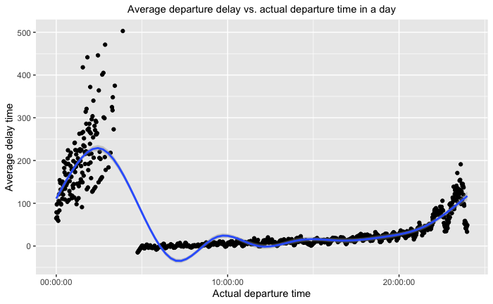

```r
library(hms)

# Convert dep_time and sched_dep_time columns to show only the time of the departures in a day
flights_time <- flights_dt %>%
  mutate(
    dep_time = as_hms(format(as.POSIXct(dep_time), format = "%H:%M:%S")),
    sched_dep_time = as_hms(format(as.POSIXct(sched_dep_time), format = "%H:%M:%S")))

# Find the average dep_delay by actual departure time in a day
(actual_dep_time <- flights_time %>%
  group_by(dep_time) %>%
  summarise(ave_delay = mean(dep_delay)) %>%
  ggplot(aes(dep_time, ave_delay)) +
  geom_point() +
  geom_smooth() +
  xlab ("Actual departure time") +
  ylab("Average delay time") +
  labs(title = "Average departure delay vs. actual departure time in a day") +
  theme(plot.title = element_text(hjust = 0.5, size = 11)))
```

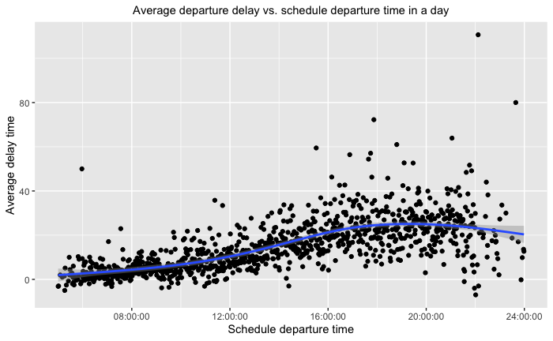

```r
# Find the average dep_delay by schedule departure time in a day
(sched_dep_time <- flights_time %>%
  group_by(sched_dep_time) %>%
  summarise(ave_delay = mean(dep_delay)) %>%
  ggplot(aes(sched_dep_time, ave_delay)) +
  geom_point() +
  geom_smooth() +
  xlab ("Schedule departure time") +
  ylab("Average delay time") +
  labs(title = "Average departure delay vs. schedule departure time in a day") +
  theme(plot.title = element_text(hjust = 0.5, size = 11)))
```

4. On what day of the week should you leave if you want to minimize the chance of a delay?, What hour of the day? Does the hours of the day depend on the day of the week? Justify the choice of column you used to determine this. (You can choose to determine this graphically or numerically.) [3 marks]

```r
# Mutate sched_dep_time columns to show a departure day in a week
(flights_day_week <- flights_dt %>%
  mutate(sched_dep_day_week = wday(sched_dep_time, label = TRUE, abbr = FALSE)) %>%
  select(sched_dep_day_week, everything()) %>%
  group_by(sched_dep_day_week) %>%
  summarise(ave_delay = mean(dep_delay)))
```

| sched_dep_day_week | ave_delay |
| --- | --- |
| Sunday | 11.495974 |
| Monday | 14.734220 |
| Tuesday | 10.591532 |
| Wednesday | 11.699198 |
| Thursday | 16.064837 |
| Friday | 14.660643 |
| Saturday | 7.620118 |

```r
# Find which hour has the minimum delay
(min_delay_hour <- flights_dt %>%
    mutate(hour = hour(sched_dep_time)) %>%
    group_by(hour) %>%
    summarise(ave_delay = mean(dep_delay)))
```

| hour | ave_delay |
| --- | --- |
| 5 | 0.6877572 |
| 6 | 1.5990901 |
| 7 | 1.9066442 |
| 8 | 4.1196176 |
| 9 | 4.5556112 |
| 10 | 6.4674185 |
| 11 | 7.1676315 |
| 12 | 8.5392923 |
| 13 | 11.3533333 |
| 14 | 13.7298412 |

[output cut: 9 more lines]

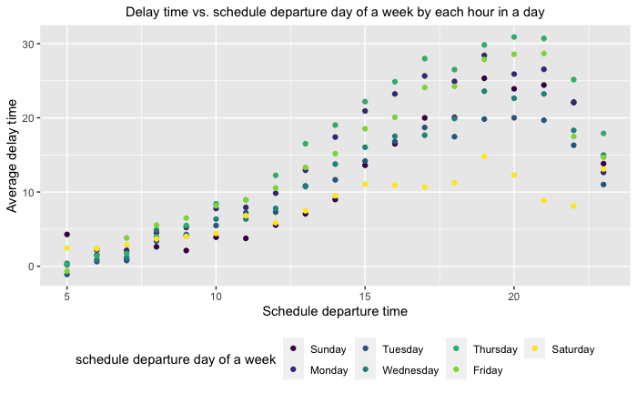

```r
# Mutate sched_dep_time columns to show a departure day in a week
flights_day_week_hour <- flights_dt %>%
  mutate(
    sched_dep_day_week = wday(sched_dep_time, label = TRUE, abbr = FALSE),
    hour = hour(sched_dep_time)) %>%
  select(sched_dep_day_week, hour, everything()) %>%
  group_by(sched_dep_day_week, hour) %>%
  summarise(ave_delay = mean(dep_delay))
  # Plot the delay time vs. schedule departure day of a week by each hour in a day
flights_day_week_hour %>%
  ggplot(aes(hour, ave_delay, color = sched_dep_day_week)) +
  geom_point() +
  xlab ("Schedule departure time") +
  ylab("Average delay time") +
  labs(title = "Delay time vs. schedule departure day of a week by each hour in a day") +
  guides(color = guide_legend(title = "schedule departure day of a week")) +
  theme(
    plot.title = element_text(hjust = 0.5, size = 11),
    legend.position = "bottom")
```

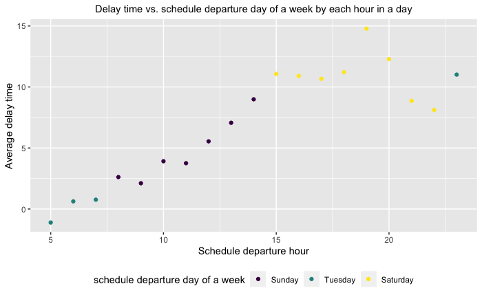

```r
# Find which day of a week has the minimum delay time for each hour of a day
day_week_min_delay <- flights_day_week_hour %>%
  group_by(hour)  %>%
  slice(which.min(ave_delay))

# Plot which day of a week has the minimum delay time for each hour of a day
day_week_min_delay %>%
  ggplot(aes(hour, ave_delay, color = sched_dep_day_week)) +
  geom_point() +
  xlab ("Schedule departure hour") +
  ylab("Average delay time") +
  labs(title = "Delay time vs. schedule departure day of a week by each hour in a day") +
  guides(color = guide_legend(title = "schedule departure day of a week")) +
  theme(
    plot.title = element_text(hjust = 0.5, size = 11),
    legend.position = "bottom")
```